# Ilustración de la regresión logística

Juan David Ospina Arango Analítica Predictiva Universidad Nacional de Colombia

25 de junio de 2020

Tomado [Evaluating logistic regression models](https://www.r-bloggers.com/evaluating-logistic-regression-models/).

Se trabajará con el conjunto de datos *GermanCredit* del paquete *caret*:

```r
library(caret)
data(GermanCredit)
```

Para ver las variables que contiene este conjunto de datos se puede hacer:

```r
names(GermanCredit)
```

```
##  [1] "Duration"
##  [2] "Amount"
##  [3] "InstallmentRatePercentage"
##  [4] "ResidenceDuration"
##  [5] "Age"
##  [6] "NumberExistingCredits"
##  [7] "NumberPeopleMaintenance"
##  [8] "Telephone"
##  [9] "ForeignWorker"
## [10] "Class"
## [11] "CheckingAccountStatus.lt.0"
## [12] "CheckingAccountStatus.0.to.200"
## [13] "CheckingAccountStatus.gt.200"
## [14] "CheckingAccountStatus.none"
## [15] "CreditHistory.NoCredit.AllPaid"
```

[output cut: 47 more lines]

El paquete *caret* contiene un amplio número de funciones para entrenar modelos de clasificación de diferentes tipos y también permite compararlos. Esta ilustración muestra el uso de las funciones básicas de R para este tipo de análisis.

# Particionamiento del conjunto de datos

Se parte el conjunto de datos en dos partes: entrenamiento (75%) y validación (25%):

```r
N<-dim(GermanCredit)[1] # Número de filas de la base de datos
N_train<-round(N*0.75)
set.seed(57)
id_train<-sample(N,size=N_train,replace=FALSE)
data_train<-GermanCredit[id_train,] # Conjunto de entrenamiento
data_vali<-GermanCredit[-id_train,] # Conjunto de validación
```

# Entrenamiento (estimación) de un modelo de regresión logística

Para entrenar (o estimar) el modelo de regresión logística se utilizará la función *glm* de la base de R, con el argumento *family=“binomial”*:

```r
modelo1_lr<-glm(Class~ Age + ForeignWorker + Property.RealEstate + Housing.Own +
                   CreditHistory.Critical,data=data_train,family="binomial")
## Atención: la inclusión de la variable ForeignWorker puede tener implicaciones éticas importantes ya que podría desfavorecer a una población.
```

Para ver los resultados utilizamos la función *summary*:

```r
summary(modelo1_lr)
```

```
##
## Call:
## glm(formula = Class ~ Age + ForeignWorker + Property.RealEstate +
##     Housing.Own + CreditHistory.Critical, family = "binomial",
##     data = data_train)
##
## Deviance Residuals:
##     Min       1Q   Median       3Q      Max
## -2.2151  -1.3078   0.6594   0.9229   1.1569
##
## Coefficients:
##                         Estimate Std. Error z value Pr(>|z|)
## (Intercept)             1.139808   0.806405   1.413   0.1575
## Age                     0.010769   0.007445   1.446   0.1481
## ForeignWorker          -1.306755   0.757963  -1.724   0.0847 .
## Property.RealEstate     0.358452   0.193041   1.857   0.0633 .
## Housing.Own             0.423275   0.177068   2.390   0.0168 *
## CreditHistory.Critical  0.868291   0.202513   4.288 1.81e-05 ***
## ---
## Signif. codes:  0 '***' 0.001 '**' 0.01 '*' 0.05 '.' 0.1 ' ' 1
##
## (Dispersion parameter for binomial family taken to be 1)
##
##     Null deviance: 916.30  on 749  degrees of freedom
## Residual deviance: 874.33  on 744  degrees of freedom
## AIC: 886.33
##
## Number of Fisher Scoring iterations: 4
```

Para ver los coeficientes en la escala exponencial hacemos:

```r
exp(coef(modelo1_lr))
```

```
##            (Intercept)                    Age          ForeignWorker
##              3.1261679              1.0108274              0.2706971
##    Property.RealEstate            Housing.Own CreditHistory.Critical
##              1.4311124              1.5269535              2.3828344
```

# Evaluación del modelo

## Curva ROC

A continuación se evalúa el modelo utilizando el área bajo la curva de operación característica (AUC):

```r
library(pROC)
prob_train<-predict(modelo1_lr,type="response")
prob_vali<-predict(modelo1_lr,newdata = data_vali,type="response")
```

```r
roc_train<-roc(data_train$Class~prob_train)
roc_vali<-roc(data_vali$Class~prob_vali)
```

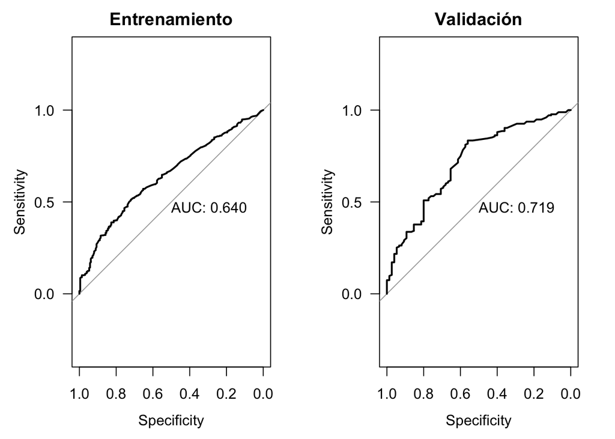

```r
par(mfrow=c(1,2))
plot(roc_train,las=1,print.auc=TRUE,main="Entrenamiento")
plot(roc_vali,las=1,print.auc=TRUE,main="Validación")
```

## Probabilidades agrupadas

Esta técnica consiste en:

1. Ordenar las probabilidades predichas de menor a mayor
2. Agrupar las probabilidades en $K$ grupos
3. Para cada grupo calcular la probabilidad promedio y la tasa de ocurrencia del evento

Para los datos de entrenamiento utilizaremos $K=10$, lo que quiere decir que tendremos 10 grupos cada uno de 75 observaciones:

```r
prob_train_sorted<-sort(prob_train) # ordena las probabilidades de menor a mayor
orden<-sort(prob_train,index.return=TRUE)$ix # contiene los índices ordenados

# Organizamos las probabilidades ordenadas en una matriz donde cada
# fila es un grupo y luego obtenemos el promedio de cada fila:
prob_train_sorted_mat<-matrix(prob_train_sorted,ncol=75,byrow=TRUE)
p_media_train<-apply(prob_train_sorted_mat,1,mean)

# Ordenamos los casos para que cada caso corresponda a la probabilidad
# predicha,luego los ponemos en una matriz donde cada fila es un grupo
# y finalmente obtenemos el promedio de cada fila (tasa de ocurrencia):
prob_casos_train<-as.numeric(data_train$Class[orden])-1
prob_casos_train_mat<-matrix((prob_casos_train),ncol=75,byrow=TRUE)
p_media_casos_train<-apply(prob_casos_train_mat,1,mean)
```

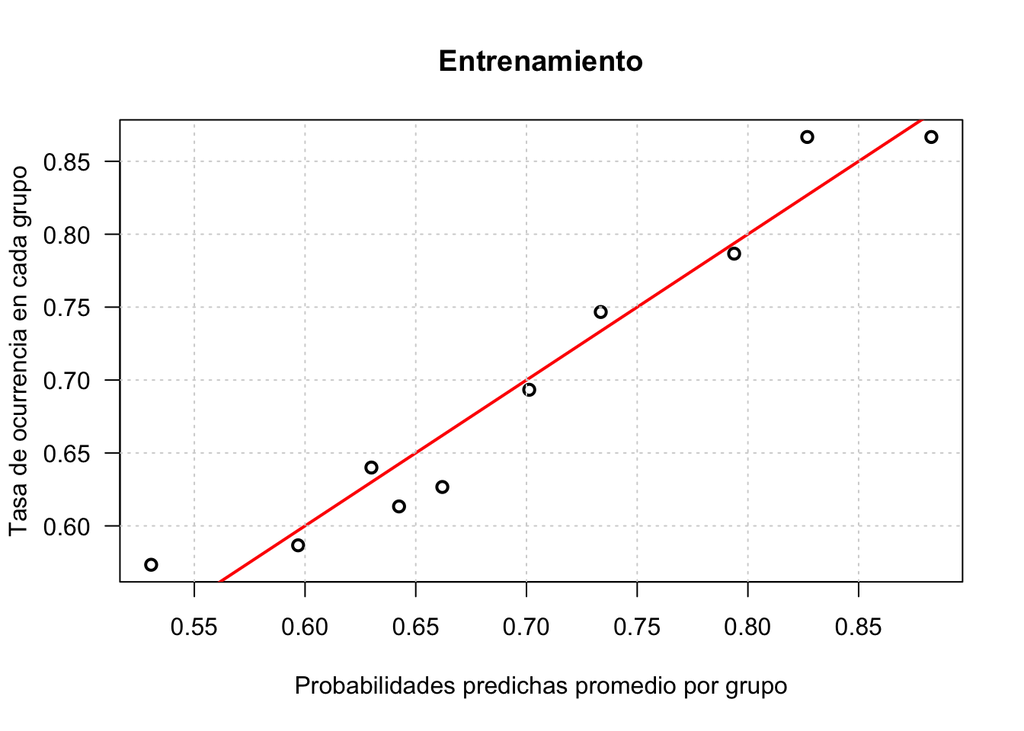

```r
plot(p_media_train,p_media_casos_train,
     main="Entrenamiento",
     xlab="Probabilidades predichas promedio por grupo",
     ylab="Tasa de ocurrencia en cada grupo",lwd=2,las=1)
abline(a=0,b=1,lwd=2,col="red")
grid()
```

Para la validación utilizaremos $K=5$ y el siguiente código:

```r
prob_vali_sorted<-sort(prob_vali) # ordena las probabilidades de menor a mayor
orden_vali<-sort(prob_vali,index.return=TRUE)$ix # contiene los índices ordenados

# Organizamos las probabilidades ordenadas en una matriz donde cada
# fila es un grupo y luego obtenemos el promedio de cada fila:
prob_vali_sorted_mat<-matrix(prob_vali_sorted,ncol=50,byrow=TRUE)
p_media_vali<-apply(prob_vali_sorted_mat,1,mean)

# Ordenamos los casos para que cada caso corresponda a la probabilidad
# predicha,luego los ponemos en una matriz donde cada fila es un grupo
# y finalmente obtenemos el promedio de cada fila (tasa de ocurrencia):
prob_casos_vali<-as.numeric(data_vali$Class[orden_vali])-1
prob_casos_vali_mat<-matrix((prob_casos_vali),ncol=50,byrow=TRUE)
p_media_casos_vali<-apply(prob_casos_vali_mat,1,mean)
```

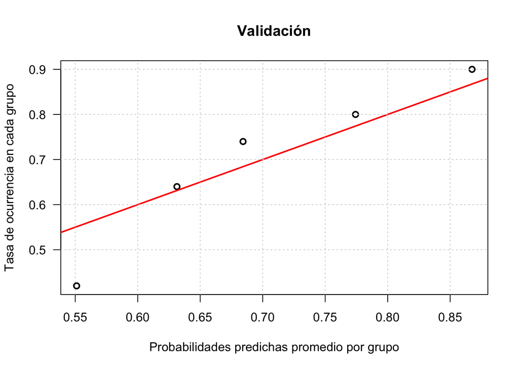

```r
plot(p_media_vali,p_media_casos_vali,
     main="Validación",
     xlab="Probabilidades predichas promedio por grupo",
     ylab="Tasa de ocurrencia en cada grupo",lwd=2,las=1)
abline(a=0,b=1,lwd=2,col="red")
grid()
```

## C-index

El índice de concordancia o C-index, sirve para saber si las probabilidades predichas por el modelo son coherentes con lo ocurrido. Supongamos que se extraen dos individuos al azar y que en uno de ellos se observa el evento de interés. Este par será concordante si la probabilidad predicha es más alta para el individuo en el que se observa el evento de interés. El C-index mide la proporción de pares concordantes sobre todos los pares posibles y coincide con el área bajo la curva ROC (AUC).

```r
library(rms)
modelo2_lr<-lrm(Class~ Age + ForeignWorker + Property.RealEstate + Housing.Own +
                   CreditHistory.Critical,data=data_train)
print(modelo2_lr)
```

```
## Logistic Regression Model
##
##  lrm(formula = Class ~ Age + ForeignWorker + Property.RealEstate +
##      Housing.Own + CreditHistory.Critical, data = data_train)
##
##                          Model Likelihood    Discrimination    Rank Discrim.
##                                Ratio Test           Indexes          Indexes
##  Obs            750    LR chi2      41.97    R2       0.077    C       0.640
##   Bad           225    d.f.             5    g        0.635    Dxy     0.280
##   Good          525    Pr(> chi2) <0.0001    gr       1.887    gamma   0.283
##  max |deriv| 0.0003                          gp       0.120    tau-a   0.118
##                                              Brier    0.199
##
##                         Coef    S.E.   Wald Z Pr(>|Z|)
##  Intercept               1.1398 0.8067  1.41  0.1577
##  Age                     0.0108 0.0074  1.45  0.1481
##  ForeignWorker          -1.3068 0.7583 -1.72  0.0848
##  Property.RealEstate     0.3585 0.1930  1.86  0.0633
##  Housing.Own             0.4233 0.1771  2.39  0.0168
##  CreditHistory.Critical  0.8683 0.2025  4.29  <0.0001
##
```